# P04_Explore_And_Summarize_Data

2016 Presidential Campaign Financial Contributions - All Candidates

## Dataset Overview

```
## [1] 426057     18
```

```
##  [1] "cmte_id"           "cand_id"           "cand_nm"
##  [4] "contbr_nm"         "contbr_city"       "contbr_st"
##  [7] "contbr_zip"        "contbr_employer"   "contbr_occupation"
## [10] "contb_receipt_amt" "contb_receipt_dt"  "receipt_desc"
## [13] "memo_cd"           "memo_text"         "form_tp"
## [16] "file_num"          "tran_id"           "election_tp"
```

```
##    cmte_id               cand_id                            cand_nm
##  Length:426057      P00003392:184378   Clinton, Hillary Rodham  :184378
##  Class :character   P60007168: 82523   Sanders, Bernard         : 82523
##  Mode  :character   P80001571: 78970   Trump, Donald J.         : 78970
##                     P60006111: 29153   Cruz, Rafael Edward 'Ted': 29153
##                     P60006723: 20472   Rubio, Marco             : 20472
##                     P60005915: 16074   Carson, Benjamin S.      : 16074
##                     (Other)  : 14487   (Other)                  : 14487
##              contbr_nm        contbr_city     contbr_st
##  LINGOR, MARGARET :   294   MIAMI   : 25317   FL:426057
##  MCGUINNESS, DIANE:   261   TAMPA   : 14812
##  SAIFF, IVAN      :   259   ORLANDO : 12950
##  BAILEY, ANGELA   :   237   NAPLES  : 12577
##  NASH, SANDY      :   218   SARASOTA: 11500
##  STANLEY, ANTHONY :   218   (Other) :348899
##  (Other)          :424570   NA's    :     2
##    contbr_zip                     contbr_employer
##  Min.   :        3   RETIRED              : 85832
##  1st Qu.:321632264   N/A                  : 66325
##  Median :331313214   SELF-EMPLOYED        : 29404
##  Mean   :263365576   NONE                 : 24707
##  3rd Qu.:336105620   INFORMATION REQUESTED: 20037
##  Max.   :349978929   (Other)              :199488
##  NA's   :6           NA's                 :   264
##              contbr_occupation  contb_receipt_amt   contb_receipt_dt
##  RETIRED              :136253   Min.   :-20000.0   12-JUL-16:  6876
##  NOT EMPLOYED         : 33103   1st Qu.:    15.0   11-JUL-16:  6092
##  INFORMATION REQUESTED: 19901   Median :    30.0   06-JUL-16:  3752
##  ATTORNEY             : 10115   Mean   :   136.2   29-FEB-16:  3398
##  PHYSICIAN            :  6071   3rd Qu.:   100.0   19-JUL-16:  3106
##  (Other)              :220553   Max.   : 20000.0   31-OCT-16:  3097
##  NA's                 :    61                      (Other)  :399736
##                      receipt_desc    memo_cd
##                            :418057    :324252
##  Refund                    :  3720   X:101805
##  REDESIGNATION FROM PRIMARY:   999
##  REDESIGNATION TO GENERAL  :   998
##  REATTRIBUTION TO SPOUSE   :   456
##  REATTRIBUTION FROM SPOUSE :   450
##  (Other)                   :  1377
##                                memo_text       form_tp
##                                     :306323   SA17A:325018
##  * EARMARKED CONTRIBUTION: SEE BELOW: 80368   SA18 : 97319
##  * HILLARY VICTORY FUND             : 32992   SB28A:  3720
##  REDESIGNATION FROM PRIMARY         :   999
##  REDESIGNATION TO GENERAL           :   998
##  EARMARKED FROM MAKE DC LISTEN      :   532
##  (Other)                            :  3845
##     file_num                       tran_id       election_tp
##  Min.   :1003942   A587D73F5F36B4479B05:     5        :  1244
##  1st Qu.:1077916   A0C59999978424AC4931:     4   G2016:153073
##  Median :1104813   AE049043E90AB4BB8A37:     4   O2016:    54
##  Mean   :1100867   A59887ABCE6F64A2EB91:     3   P2016:271685
##  3rd Qu.:1133832   AABA56134F3604F6786A:     3   P2020:     1
##  Max.   :1146285   C11848970           :     3
##                    (Other)             :426035
```

Our dataset consists of 18 variables, with almost 426,057 observations.

Let us see some sample data

```
##     cmte_id   cand_id          cand_nm       contbr_nm contbr_city
## 1 C00580100 P80001571 Trump, Donald J. SELLAS, KRISTEN  CLEARWATER
## 2 C00580100 P80001571 Trump, Donald J.  SELLERS, CHRIS  VERO BEACH
##   contbr_st contbr_zip            contbr_employer
## 1        FL      33759                    RETIRED
## 2        FL      32966 PROST BEVERAGE COMPANY LLC
##             contbr_occupation contb_receipt_amt contb_receipt_dt
## 1                     RETIRED             68.37        09-NOV-16
## 2 BEVERAGE INDUSTRY EXECUTIVE             80.00        19-NOV-16
##   receipt_desc memo_cd memo_text form_tp file_num     tran_id election_tp
## 1                    X              SA18  1146165 SA18.145176       G2016
## 2                    X              SA18  1146165 SA18.120235       G2016
```

According [FEC.gov](http://www.fec.gov/info/contriblimitschart1718.pdfm) : Individual’s contribution limit is $2700 so I’ll eliminate any negative amounts (refunds) and amounts that exceed the contribution’s limit .

```
## [1] 417573     18
```

```
##     cmte_id   cand_id                 cand_nm          contbr_nm
## 1 C00580100 P80001571        Trump, Donald J.    SELLAS, KRISTEN
## 2 C00580100 P80001571        Trump, Donald J.     SELLERS, CHRIS
## 3 C00575795 P00003392 Clinton, Hillary Rodham SCHECTER, MITCHELL
## 4 C00577130 P60007168        Sanders, Bernard LERBS, CHRISTOPHER
## 5 C00575795 P00003392 Clinton, Hillary Rodham       CHOREY, LORI
## 6 C00580100 P80001571        Trump, Donald J.     PUSINS, AUDREY
##          contbr_city contbr_st contbr_zip            contbr_employer
## 1         CLEARWATER        FL      33759                    RETIRED
## 2         VERO BEACH        FL      32966 PROST BEVERAGE COMPANY LLC
## 3         PLANTATION        FL  333243808                  TERRANOVA
## 4 GREEN COVE SPRINGS        FL  320433443                       NONE
## 5        TALLAHASSEE        FL  323121800      SWEAT THERAPY FITNESS
## 6         BOCA RATON        FL      33433                       PBSO
##             contbr_occupation contb_receipt_amt contb_receipt_dt
```

[output cut: 20 more lines]

## Univariate Plots Section

### Exploring recieved contribution amount

```
##    Min. 1st Qu.  Median    Mean 3rd Qu.    Max.
##    0.15   19.00   35.00  144.60  100.00 2700.00
```

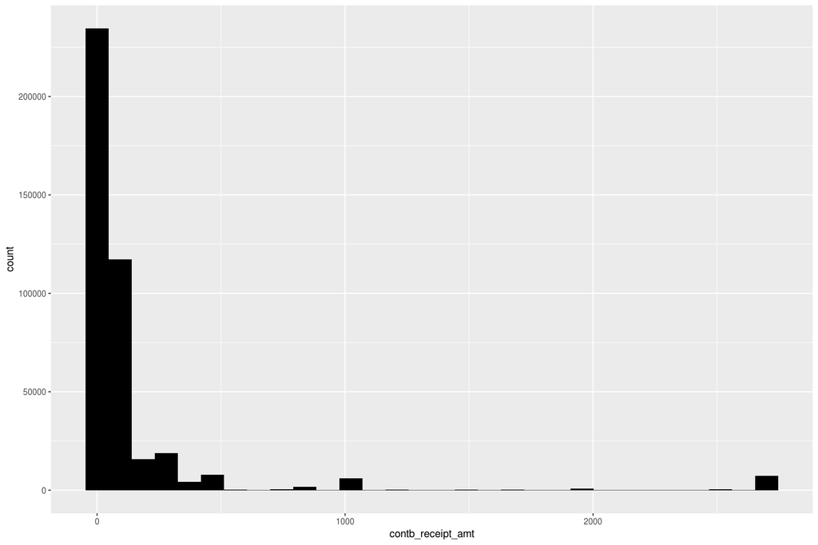

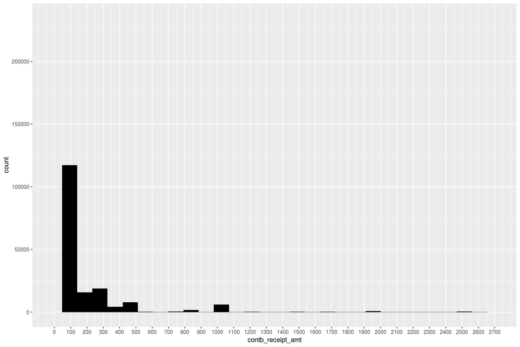

Frm above, We can see about 120,000 contributor donated about less $145 .

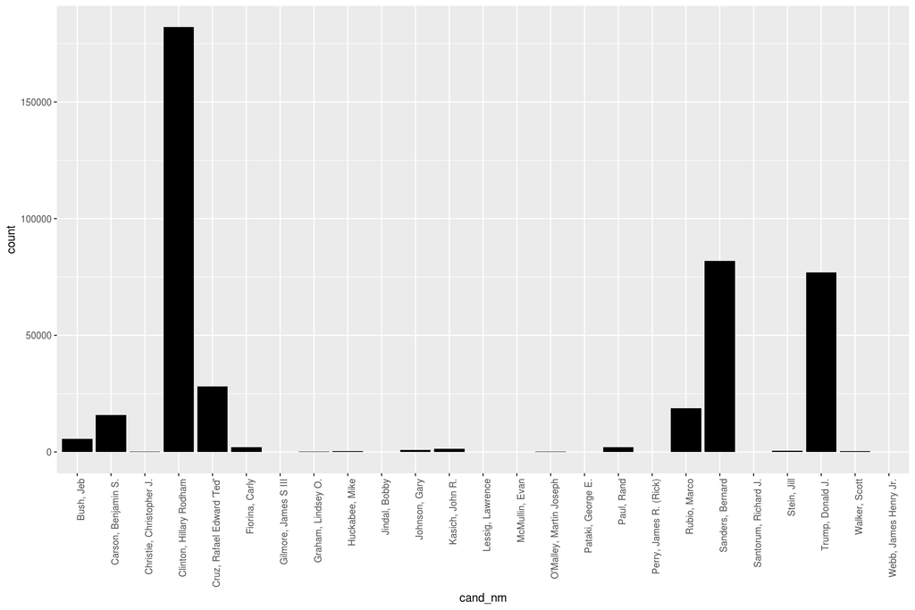

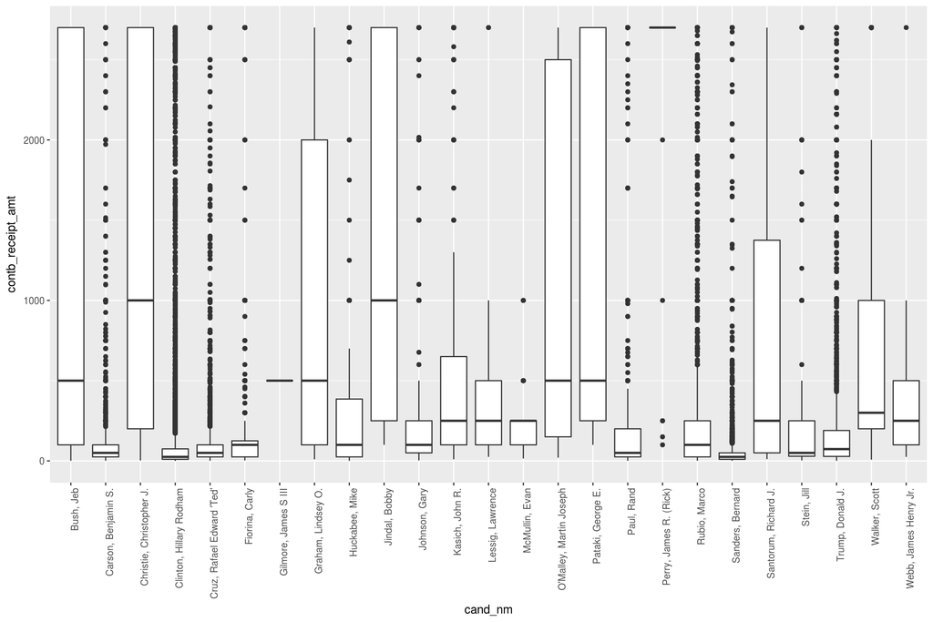

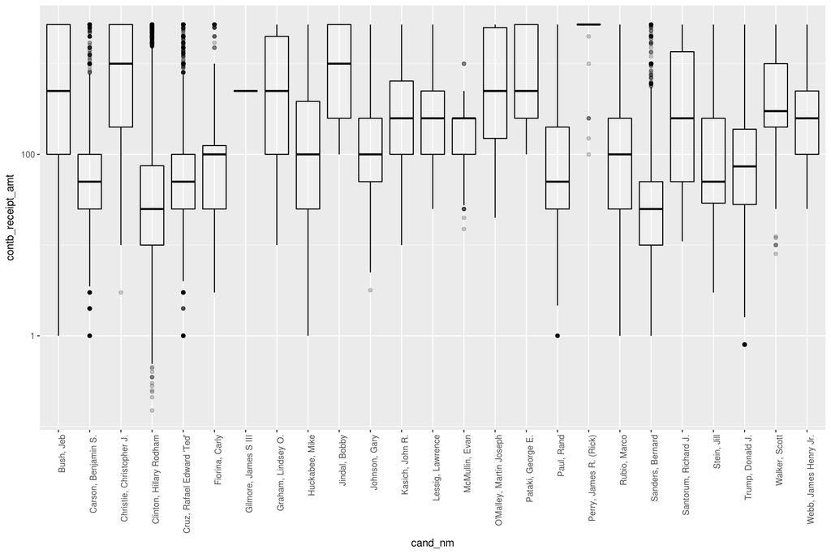

Hillary Clinton earned the lion’s share of recieved contribution amount among other candidates, followed by Bernard Sanders and Donald Trump.

### Now, I’m going to explore top 10 cities with most contribution number/amount :

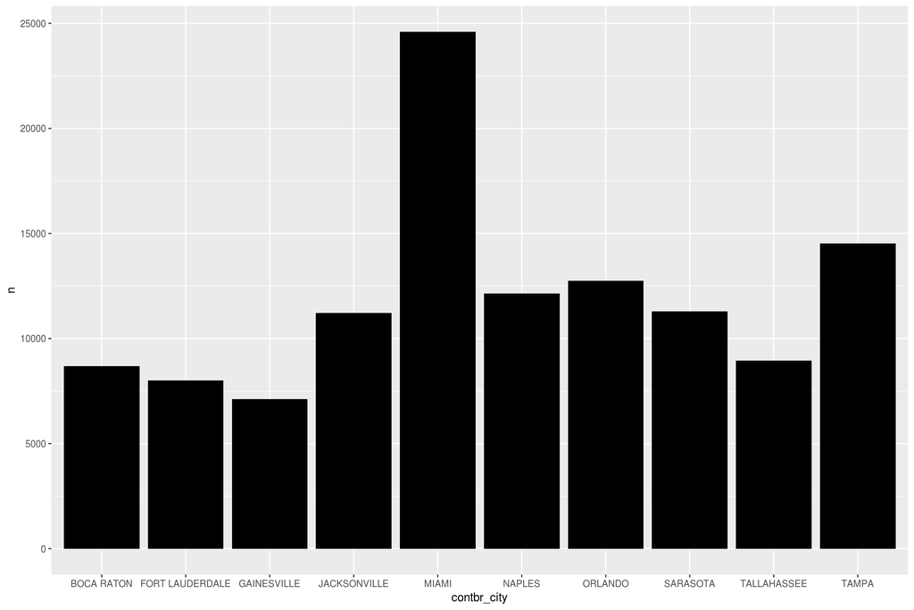

Looking at our barchart, I was surprised that Jacksonville wasn’t the city with highest contribution number since it’s the largest city in Florida. Seeing Miami, Tampa and Orlando among the top 5 made a lot of sense. However, I was a bit shocked that Naples slightly surpassed Jacksonville. One justification I could think of is that Naples is considered of the richest cities in Florida state.

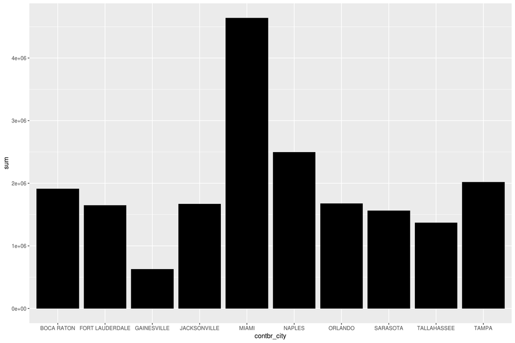

Interestingly, two small cities Naples and Boca Raton had significant contribution comparing to other large cities such as Orlando and Jacksonville.

## Bivariate Plots Section

### Exploring contribtuin amount and contributin date :

Let’s see how contribution is distrubted across years

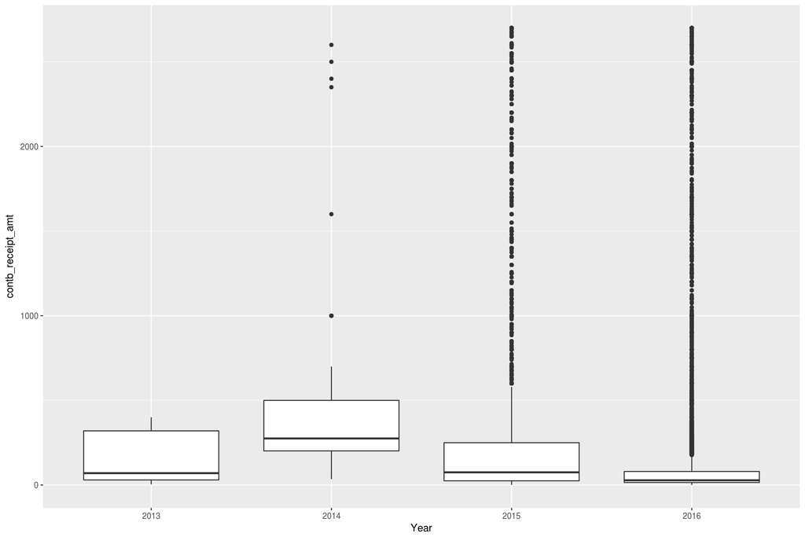

I expected 2016 to have highest contribution amount mean comparing to other years, since it’s the election year and presidential race gets closer as we approach nominees announcement date. However, data proved me wrong as I clearly see 2014 has the highest contribtuon amount mean .

Let me explore election year (2016) further :

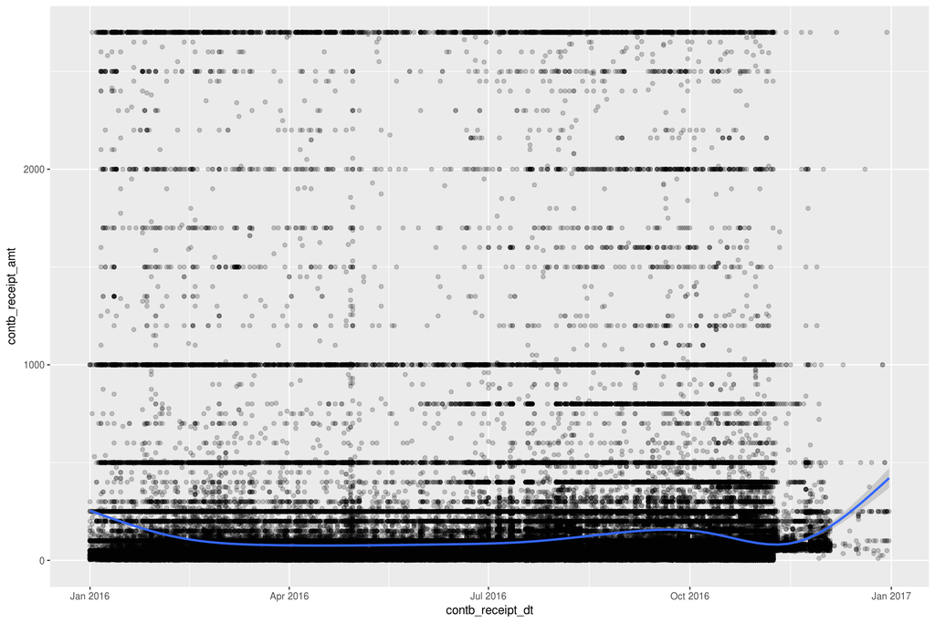

Let’s see monthly sum/mean/median of contribution amount for 2016 :

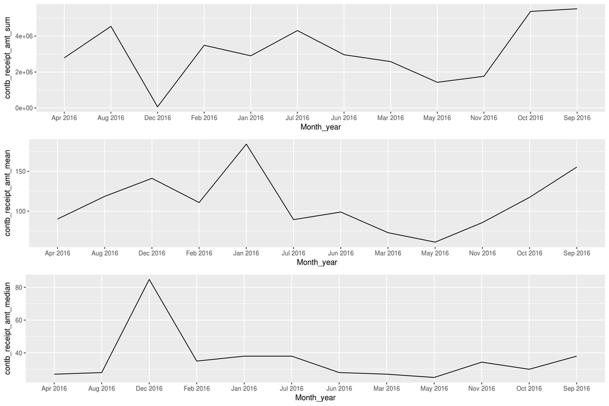

### Exploring contribtuin amount and contbr_occupation :

```
## # A tibble: 10 × 4
##    contbr_occupation contb_receipt_amt_sum contb_receipt_amt_mean      n
##               <fctr>                 <dbl>                  <dbl>  <int>
## 1            RETIRED            16078862.4              119.86449 134142
## 2           ATTORNEY             3472662.9              345.98614  10037
## 3          HOMEMAKER             2125030.6              378.59087   5613
## 4       NOT EMPLOYED             1498486.4               45.28380  33091
## 5          PHYSICIAN             1317838.7              219.12848   6014
## 6         CONSULTANT              904977.7              220.72626   4100
## 7              SALES              397271.9               98.28598   4042
## 8            TEACHER              334826.5               56.73101   5902
## 9           ENGINEER              320602.5               99.62786   3218
## 10         PROFESSOR              307817.3               78.84664   3904
```

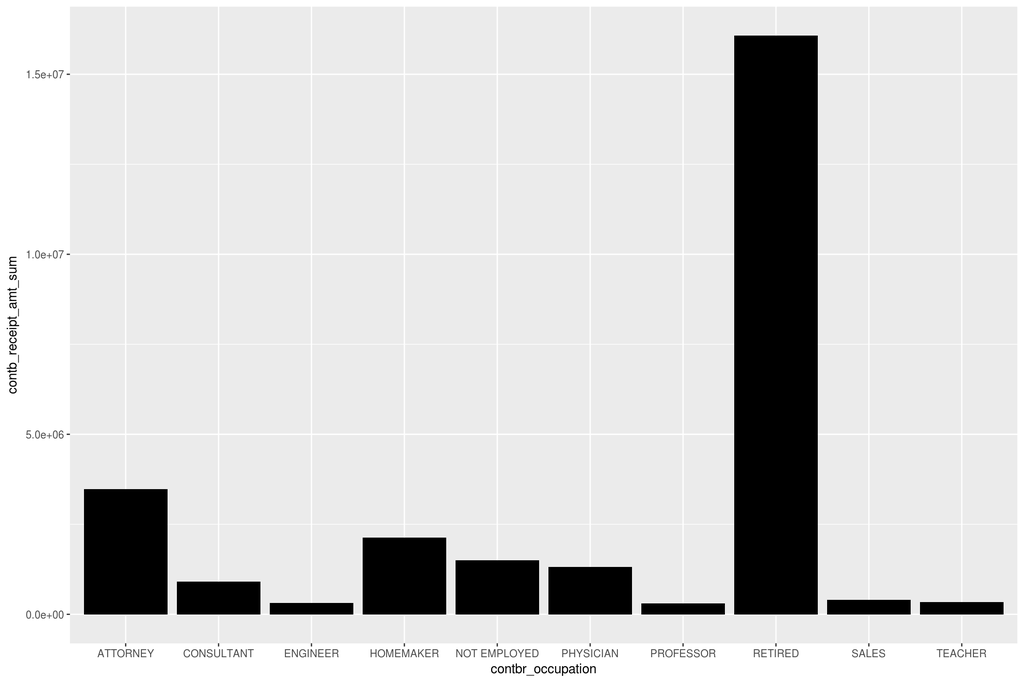

Retireds poured a lot of moeny into the elections, marking themselves as the biggest contributors among differebt occuptaions. Way behind, comes attorneys and then homemakers in the third place.

Let us what was the mean contribtuions among those top occupations :

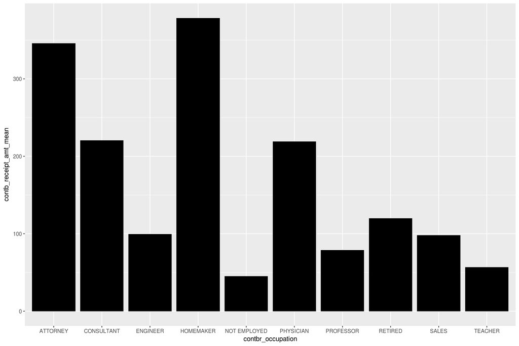

## Multivariate Plots Section

```
## Source: local data frame [20 x 5]
## Groups: cand_nm [2]
##
##                    cand_nm contbr_occupation contb_receipt_amt_sum
##                     <fctr>            <fctr>                 <dbl>
## 1  Clinton, Hillary Rodham           RETIRED            5144774.32
## 2         Trump, Donald J.           RETIRED            4988684.15
## 3  Clinton, Hillary Rodham          ATTORNEY            2332606.41
## 4  Clinton, Hillary Rodham         HOMEMAKER             648553.97
## 5  Clinton, Hillary Rodham         PHYSICIAN             552534.32
## 6  Clinton, Hillary Rodham        CONSULTANT             445398.05
## 7         Trump, Donald J.         PHYSICIAN             246654.70
## 8  Clinton, Hillary Rodham         PROFESSOR             245220.90
## 9  Clinton, Hillary Rodham      NOT EMPLOYED             239008.85
## 10 Clinton, Hillary Rodham           TEACHER             219594.37
## 11        Trump, Donald J.          ATTORNEY             149951.13
## 12        Trump, Donald J.         HOMEMAKER             148926.42
## 13        Trump, Donald J.             SALES             134478.47
## 14 Clinton, Hillary Rodham             SALES             119750.33
## 15        Trump, Donald J.        CONSULTANT             104253.49
## 16 Clinton, Hillary Rodham          ENGINEER              74068.02
## 17        Trump, Donald J.          ENGINEER              71703.71
## 18        Trump, Donald J.      NOT EMPLOYED              22144.82
## 19        Trump, Donald J.           TEACHER              18118.73
## 20        Trump, Donald J.         PROFESSOR              10538.24
## # ... with 2 more variables: contb_receipt_amt_mean <dbl>, n <int>
```

```
## [1] 20  5
```

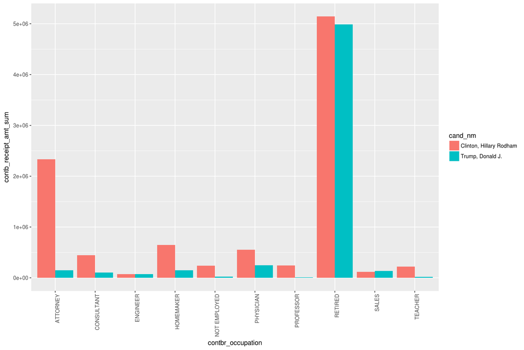

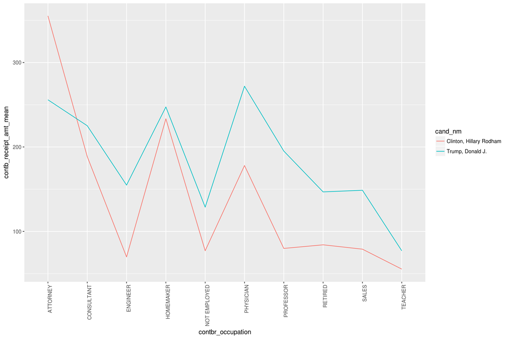

## Final Plots and Summary

### Plot One

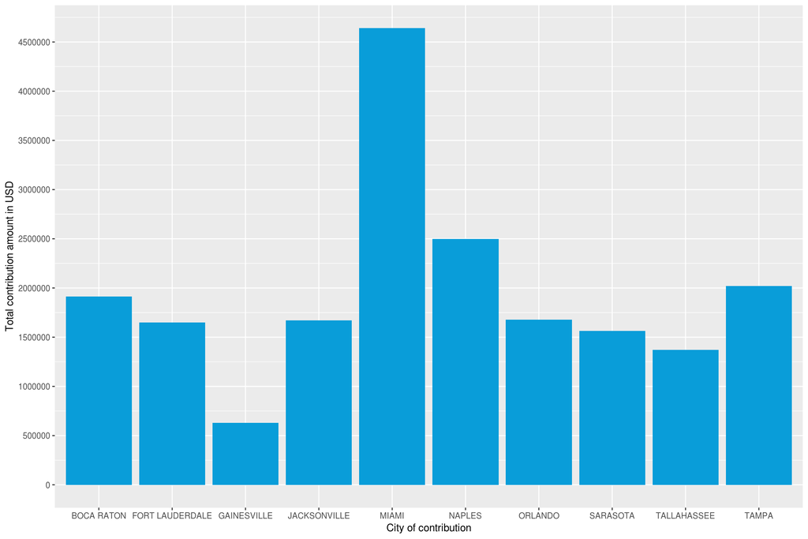

Rich citites in Florida played major role contributing to candidates. We can see how rich, small cities liek Naples and Boca Raton have more i mpact than major cities such as Jacksonville.

### Plot Two

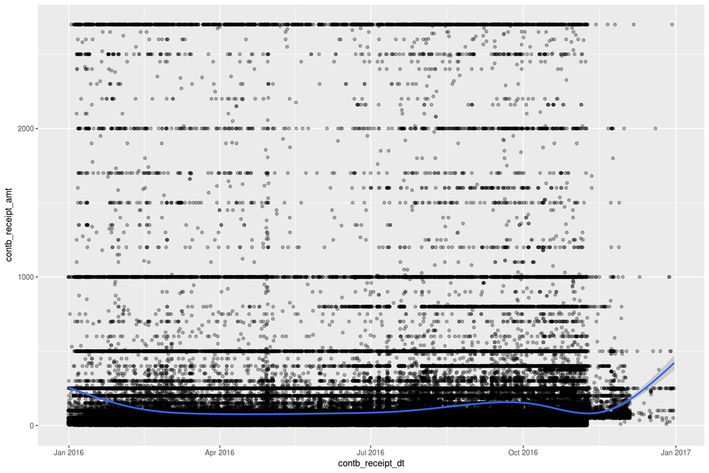

### Plot Three

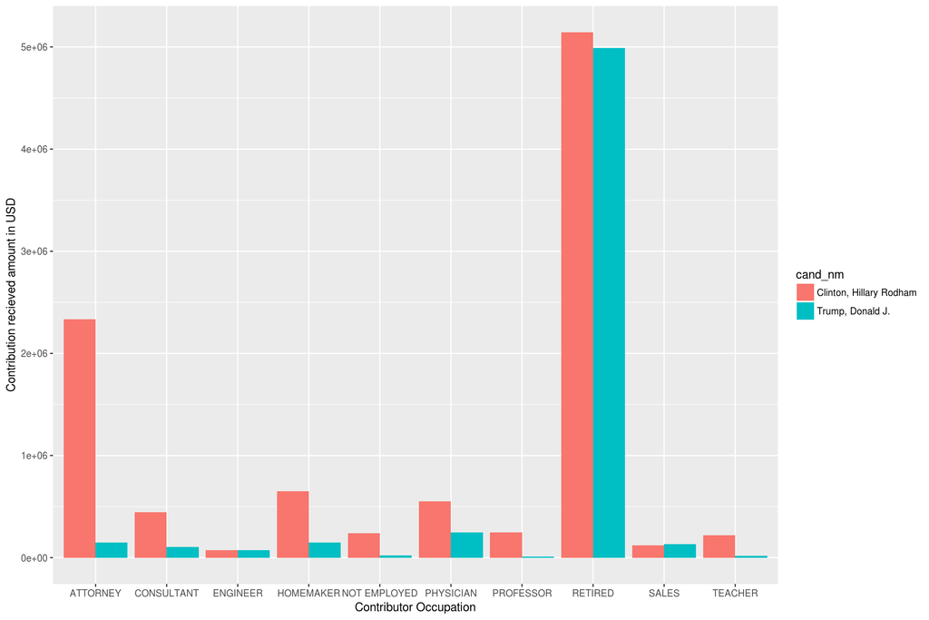

## Reflection

Florida state 2016 election contribution dataset contains more than 417573 items which were captured between 2013-10-01 and 2016-12-31. To begin, I omitted contribution above FEC limit which is $2700, and any refunes.

The average contribuion was around $145, and the minimum recieved contribution was $0.15.

Most of the contribution was made to hillary clinton, bernie sanders and Donland Trump respectivly.

Contributors from Miami, Tampa and Naples contributed the major portion of recived money.

On average, contribution amount was about $300 in 2014 which was best avergae contributon comparing to other years.

It’d be very interesting to look how condidates performed in other swing states. Further, explore contribution based on the candidate’s party and his/her background.